# Assignment 3: Model comparison

#### Checking assumptions of the updated model

Normality assumption

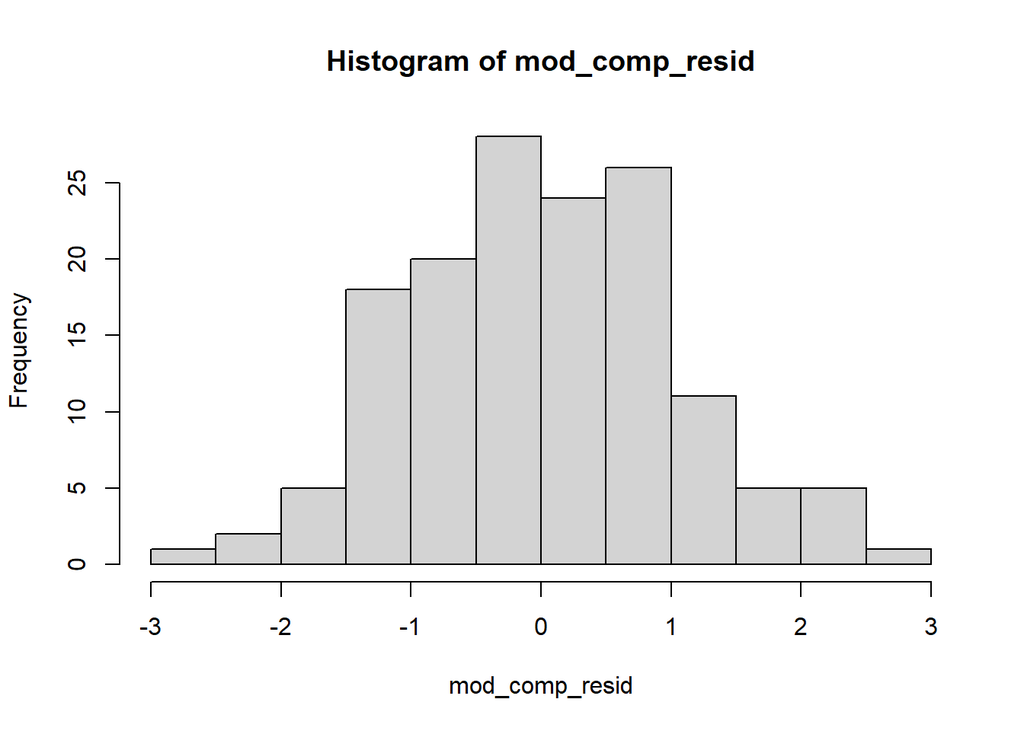

```r
mod_updated_resid <- model_updated$residuals
hist(mod_comp_resid)
```

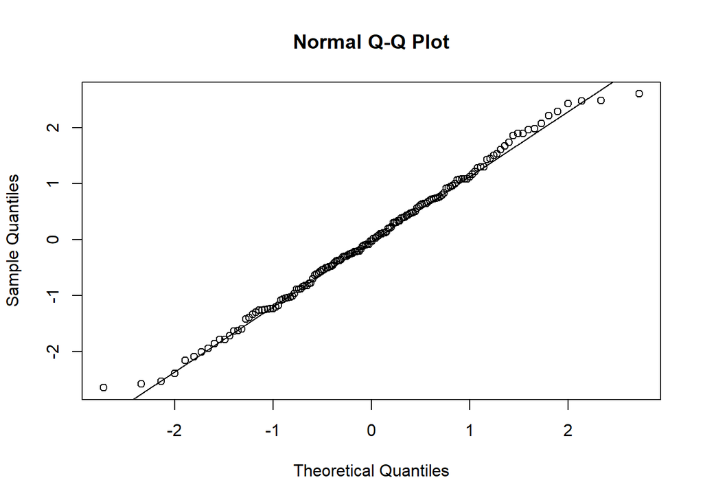

```r
# We can see from the histogram that the residuals of our simple model are normally distributed
qqnorm(mod_updated_resid)
qqline(mod_updated_resid)
```

```r
# We can use Shapiro-Wilk test to check if there is a significant difference from normal distribution
shapiro.test(mod_updated_resid)
```

```
##
##  Shapiro-Wilk normality test
##
## data:  mod_updated_resid
## W = 0.99309, p-value = 0.671
```

```r
# Result:
# There is no significant difference from normal distribution
```

Linearity assumption

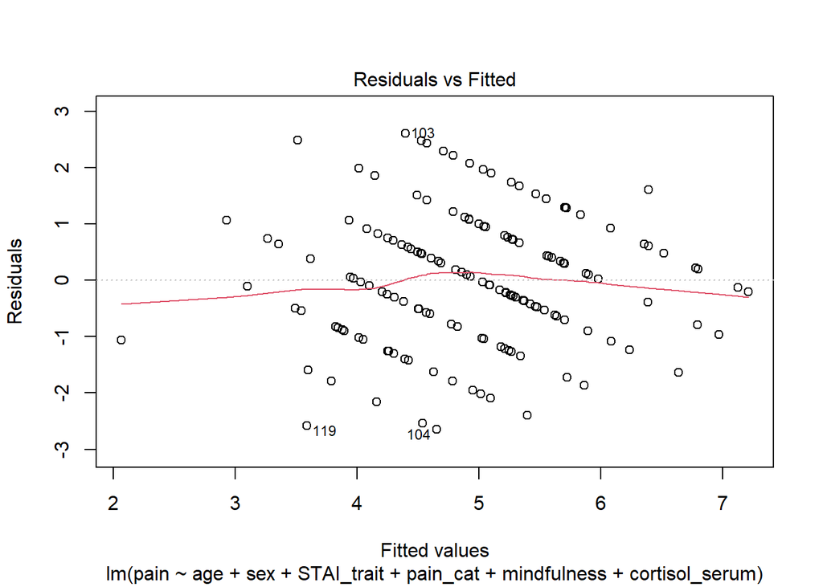

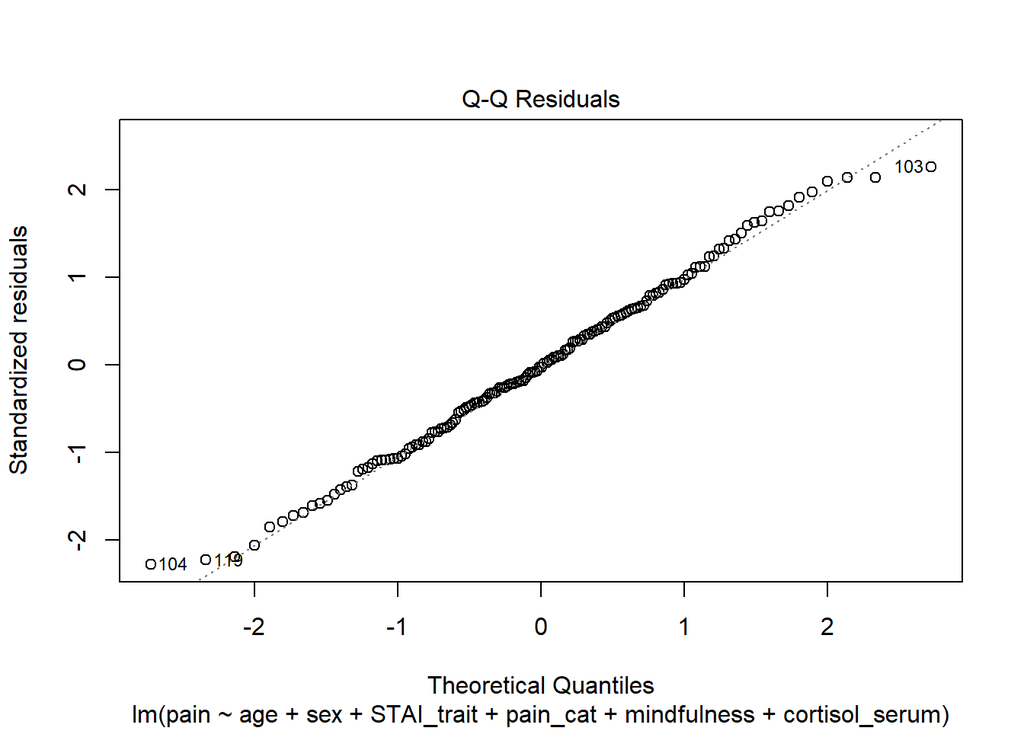

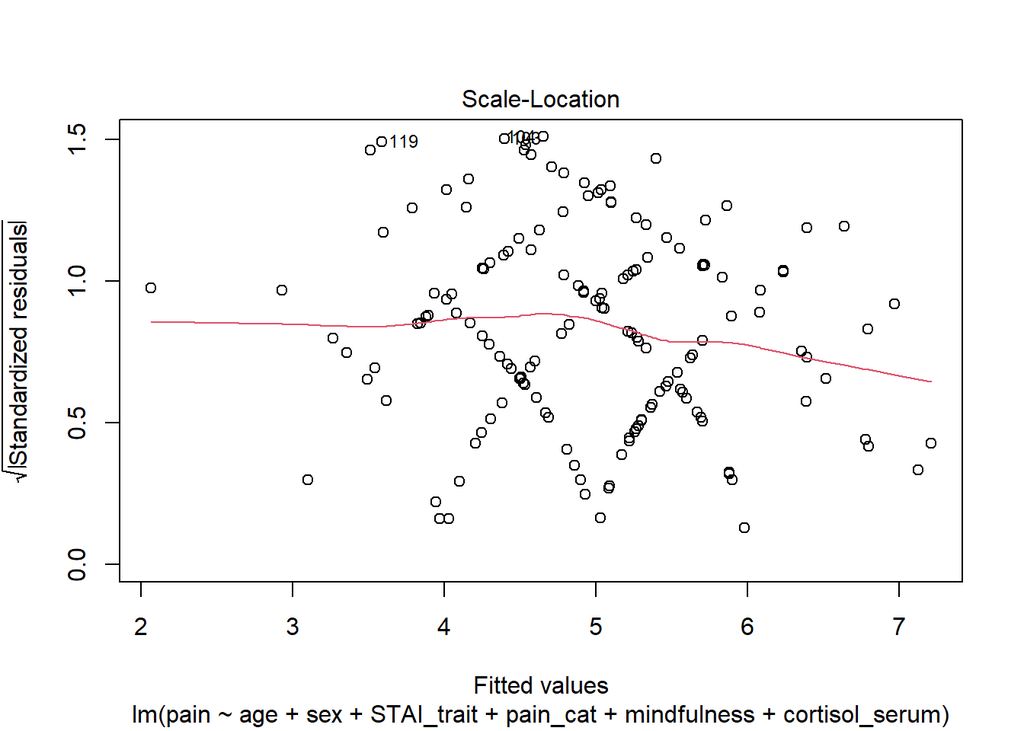

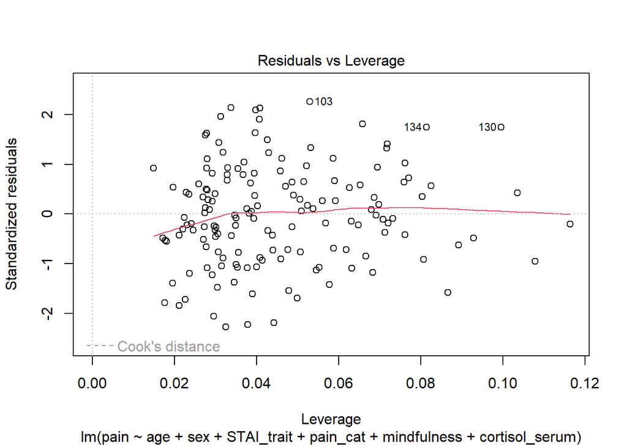

```r
plot(model_updated)
```

```r
# Linearity criteria is met
```

Homoscedasticty assumption (homogeneity of variance)

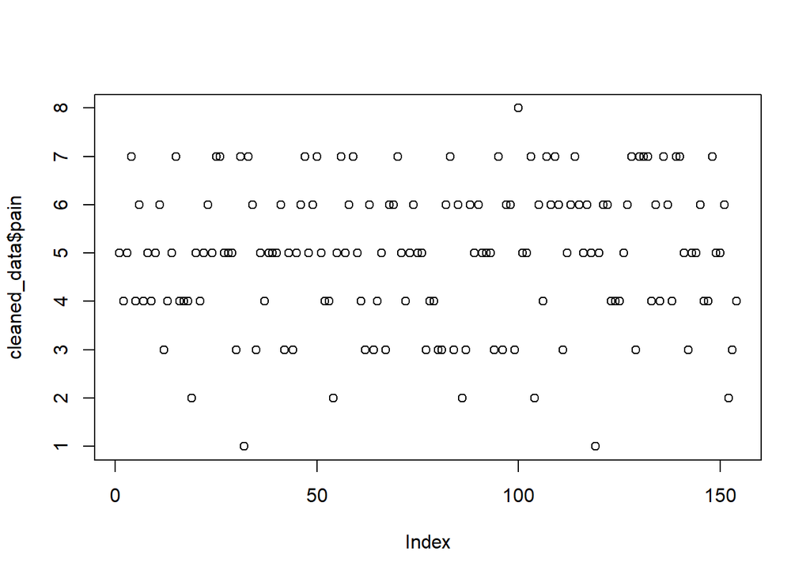

```r
plot(cleaned_data$pain)
```

```r
# Homoscedasticity assumption met
```

Multicollinearity assumption

```r
# Testing for multicollinearity assumption
# We first need a dataset without the outcome

mcoll_data <- subset(cleaned_data, select = - pain)

# recode the sex values
mcoll_data$sex_num <- ifelse(mcoll_data$sex == "male", 0, 1)

mcoll_data <- mcoll_data %>%
  select(- sex, - cd, - ID)

corr_matrix = round(cor(mcoll_data), 2)

# check for the cause of the error
# It was the ID variable being present in the dataset
#str(m_data)
```

## Model comparison

Create the simple model and get the results of the model that needs to be reported based on the What to report section.

```r
model_s_updated <- lm(pain ~ age + sex, data = cleaned_data)
summary(model_s_updated)
```

```
##
## Call:
## lm(formula = pain ~ age + sex, data = cleaned_data)
##
## Residuals:
##     Min      1Q  Median      3Q     Max
## -3.7198 -0.8651  0.1068  1.0021  3.3638
##
## Coefficients:
##             Estimate Std. Error t value Pr(>|t|)
## (Intercept)  8.31550    0.92548   8.985 9.81e-16 ***
## age         -0.08362    0.02252  -3.714 0.000287 ***
## sexmale      0.08971    0.22635   0.396 0.692407
## ---
## Signif. codes:  0 '***' 0.001 '**' 0.01 '*' 0.05 '.' 0.1 ' ' 1
##
## Residual standard error: 1.401 on 151 degrees of freedom
## Multiple R-squared:  0.08428,    Adjusted R-squared:  0.07215
## F-statistic: 6.949 on 2 and 151 DF,  p-value: 0.001298
```

```r
confint(model_s_updated)
```

```
##                  2.5 %      97.5 %
## (Intercept)  6.4869473 10.14405467
## age         -0.1281077 -0.03913344
## sexmale     -0.3575087  0.53693578
```

Create the more complex model based on the results of the model diagnostics. Also, get the results that needs to be reported based on the What to report section.

```r
model_updated <- lm(pain ~ age + sex + STAI_trait + pain_cat + mindfulness +  cortisol_serum, data = cleaned_data)
summary(model_updated)
```

```
##
## Call:
## lm(formula = pain ~ age + sex + STAI_trait + pain_cat + mindfulness +
##     cortisol_serum, data = cleaned_data)
##
## Residuals:
##      Min       1Q   Median       3Q      Max
## -2.65134 -0.82613 -0.03108  0.74584  2.60365
##
## Coefficients:
##                Estimate Std. Error t value Pr(>|t|)
## (Intercept)     1.97396    1.62538   1.214 0.226518
## age            -0.04367    0.02262  -1.931 0.055403 .
## sexmale         0.37733    0.20594   1.832 0.068944 .
## STAI_trait      0.01414    0.02689   0.526 0.599906
## pain_cat        0.07257    0.02751   2.638 0.009241 **
## mindfulness    -0.16106    0.12304  -1.309 0.192549
## cortisol_serum  0.47839    0.12566   3.807 0.000206 ***
## ---
## Signif. codes:  0 '***' 0.001 '**' 0.01 '*' 0.05 '.' 0.1 ' ' 1
##
## Residual standard error: 1.183 on 147 degrees of freedom
## Multiple R-squared:  0.3642, Adjusted R-squared:  0.3383
## F-statistic: 14.03 on 6 and 147 DF,  p-value: 1.367e-12
```

```r
confint(model_updated)
```

```
##                      2.5 %      97.5 %
## (Intercept)    -1.23816373 5.186081156
## age            -0.08837037 0.001022283
## sexmale        -0.02965998 0.784318685
## STAI_trait     -0.03901003 0.067284114
## pain_cat        0.01820124 0.126930228
## mindfulness    -0.40421007 0.082083080
## cortisol_serum  0.23006300 0.726720774
```

Compare the two models.

```r
anova(model_s_updated, model_updated)
```

```
## Analysis of Variance Table
##
## Model 1: pain ~ age + sex
## Model 2: pain ~ age + sex + STAI_trait + pain_cat + mindfulness + cortisol_serum
##   Res.Df    RSS Df Sum of Sq     F    Pr(>F)
## 1    151 296.48
## 2    147 205.85  4    90.632 16.18 5.303e-11 ***
## ---
## Signif. codes:  0 '***' 0.001 '**' 0.01 '*' 0.05 '.' 0.1 ' ' 1
```

```r
# We can test a middle block too, when we are not including any saliva measures, only demographic + psychological measures
# Lets call it model_mid_updated
# We can see that our model performance is higher while including the cortisl serum, so we can compare the simple and the complex models below

model_mid_updated <- lm(pain ~ age + sex + STAI_trait + pain_cat + mindfulness, data = cleaned_data)
summary(model_mid_updated)
```

```
##
## Call:
## lm(formula = pain ~ age + sex + STAI_trait + pain_cat + mindfulness,
##     data = cleaned_data)
##
## Residuals:
##     Min      1Q  Median      3Q     Max
## -3.1948 -0.7506  0.0535  0.8382  2.9402
##
## Coefficients:
##             Estimate Std. Error t value Pr(>|t|)
## (Intercept)  3.68467    1.63169   2.258  0.02540 *
## age         -0.07314    0.02220  -3.295  0.00123 **
## sexmale      0.25619    0.21254   1.205  0.22999
## STAI_trait   0.05282    0.02601   2.031  0.04409 *
## pain_cat     0.08628    0.02849   3.029  0.00290 **
## mindfulness -0.18103    0.12841  -1.410  0.16069
## ---
## Signif. codes:  0 '***' 0.001 '**' 0.01 '*' 0.05 '.' 0.1 ' ' 1
##
## Residual standard error: 1.236 on 148 degrees of freedom
## Multiple R-squared:  0.3015, Adjusted R-squared:  0.2779
## F-statistic: 12.78 on 5 and 148 DF,  p-value: 2.497e-10
```

# Summary report

## Description of the 2 models

```r
# In this study we compared different models for explaining the pain experience of patients.
# During the test process we dropped the cortisol_saliva measure from the more complex model, because of multicollinearity (cortisol serum and saliva had r value = 0.91)

# In the simple model we included basic demographic measures such as age and sex to predict pain report by patients who were exposed to wisdom tooth surgery
# Based on the results the model explains 7.2% of the variance (adjusted R2 = 0.072). F = 6.949, df = 151, p = 0.001. From the predictors only age was significant (p = 0.0002).

# In the more complex model we included anxiety (STAI_trait), pain carastrophisation, mindfulness and cortisol measure (serum from blood).
# In the first place 2 of the cortisol measures were present in the model, but after having not acceptable VIF value, due to multicollinearity we kept in the model the cortisol serum variable.
# Based on the results the model explains 33.8% of the variance (adjusted R2 = 0.338). F = 14.03, df = 147, p = < 0.000. From the predictors the pain catastrophisation and the cortisol serum were significant.
```

## Tables to report

```r
library(parameters)
model_parameters(model_s_updated, standardized = "refit",  include_standardized = TRUE)
```

```
## Parameter   | Coefficient |   SE |         95% CI | t(151) |      p
## -------------------------------------------------------------------
## (Intercept) |        8.32 | 0.93 | [ 6.49, 10.14] |   8.99 | < .001
## age         |       -0.08 | 0.02 | [-0.13, -0.04] |  -3.71 | < .001
## sex [male]  |        0.09 | 0.23 | [-0.36,  0.54] |   0.40 | 0.692
```

```
##
## Uncertainty intervals (equal-tailed) and p-values (two-tailed) computed
##   using a Wald t-distribution approximation.
```

```r
model_parameters(model_updated, standardized = "refit",  include_standardized = TRUE)
```

```
## Parameter      | Coefficient |   SE |        95% CI | t(147) |      p
## ---------------------------------------------------------------------
## (Intercept)    |        1.97 | 1.63 | [-1.24, 5.19] |   1.21 | 0.227
## age            |       -0.04 | 0.02 | [-0.09, 0.00] |  -1.93 | 0.055
## sex [male]     |        0.38 | 0.21 | [-0.03, 0.78] |   1.83 | 0.069
## STAI trait     |        0.01 | 0.03 | [-0.04, 0.07] |   0.53 | 0.600
## pain cat       |        0.07 | 0.03 | [ 0.02, 0.13] |   2.64 | 0.009
## mindfulness    |       -0.16 | 0.12 | [-0.40, 0.08] |  -1.31 | 0.193
## cortisol serum |        0.48 | 0.13 | [ 0.23, 0.73] |   3.81 | < .001
```

```
##
## Uncertainty intervals (equal-tailed) and p-values (two-tailed) computed
##   using a Wald t-distribution approximation.
```

## What to include in the table

```r
# Report things about the models
#  For both models you should report the model test statistics (adj.R2, F, df, and p value). Also, report the statistics describing the coefficients of the predictors in a table format (unstandardized regression coefficients and 95% confidence intervals, standardized regression coefficients (B and Beta values), and p values).
```

```r
jtools::summ(model_s_updated, scale = TRUE)
```

```
## MODEL INFO:
## Observations: 154
## Dependent Variable: pain
## Type: OLS linear regression
##
## MODEL FIT:
## F(2,151) = 6.95, p = 0.00
## R² = 0.08
## Adj. R² = 0.07
##
## Standard errors:OLS
## ------------------------------------------------
##                      Est.   S.E.   t val.      p
## ----------------- ------- ------ -------- ------
## (Intercept)          4.92   0.15    31.79   0.00
## age                 -0.42   0.11    -3.71   0.00
## sexmale              0.09   0.23     0.40   0.69
## ------------------------------------------------
##
## Continuous predictors are mean-centered and scaled by 1 s.d. The outcome variable remains in its original units.
```